# Loan Data Exploration

## Preliminary Wrangling

> This document explores a dataset containing 113,937 loans and their attributes

```python
# import all packages and set plots to be embedded inline
import random
import numpy as np
import pandas as pd
import matplotlib.pyplot as plt
import seaborn as sb

%matplotlib inline
```

> Load in your dataset and describe its properties through the questions below. Try and motivate your exploration goals through this section.

```python
#read data
data = pd.read_csv('prosperLoanData.csv')
df = data[['Term','LoanStatus','BorrowerRate','LenderYield','ProsperScore','ListingCategory (numeric)','EmploymentStatus','LoanOriginalAmount','EstimatedLoss','EstimatedReturn','IncomeVerifiable']]
df.info()
```

```
<class 'pandas.core.frame.DataFrame'>
RangeIndex: 113937 entries, 0 to 113936
Data columns (total 11 columns):
 #   Column                     Non-Null Count   Dtype
---  ------                     --------------   -----
 0   Term                       113937 non-null  int64
 1   LoanStatus                 113937 non-null  object
 2   BorrowerRate               113937 non-null  float64
 3   LenderYield                113937 non-null  float64
 4   ProsperScore               84853 non-null   float64
 5   ListingCategory (numeric)  113937 non-null  int64
 6   EmploymentStatus           111682 non-null  object
 7   LoanOriginalAmount         113937 non-null  int64
 8   EstimatedLoss              84853 non-null   float64
 9   EstimatedReturn            84853 non-null   float64
 10  IncomeVerifiable           113937 non-null  bool
dtypes: bool(1), float64(5), int64(3), object(2)
memory usage: 8.8+ MB
```

```python
df.describe()
```

|  | Term | BorrowerRate | LenderYield | ProsperScore | ListingCategory (numeric) | LoanOriginalAmount | EstimatedLoss | EstimatedReturn |
| --- | --- | --- | --- | --- | --- | --- | --- | --- |
| count | 113937.000000 | 113937.000000 | 113937.000000 | 84853.000000 | 113937.000000 | 113937.00000 | 84853.000000 | 84853.000000 |
| mean | 40.830248 | 0.192764 | 0.182701 | 5.950067 | 2.774209 | 8337.01385 | 0.080306 | 0.096068 |
| std | 10.436212 | 0.074818 | 0.074516 | 2.376501 | 3.996797 | 6245.80058 | 0.046764 | 0.030403 |
| min | 12.000000 | 0.000000 | -0.010000 | 1.000000 | 0.000000 | 1000.00000 | 0.004900 | -0.182700 |
| 25% | 36.000000 | 0.134000 | 0.124200 | 4.000000 | 1.000000 | 4000.00000 | 0.042400 | 0.074080 |
| 50% | 36.000000 | 0.184000 | 0.173000 | 6.000000 | 1.000000 | 6500.00000 | 0.072400 | 0.091700 |
| 75% | 36.000000 | 0.250000 | 0.240000 | 8.000000 | 3.000000 | 12000.00000 | 0.112000 | 0.116600 |
| max | 60.000000 | 0.497500 | 0.492500 | 11.000000 | 20.000000 | 35000.00000 | 0.366000 | 0.283700 |

```python
# high-level overview of data shape and composition
print(str(df.shape) + "\n")
print(df.dtypes)
df.head(10)
```

```
(113937, 11)

Term                           int64
LoanStatus                    object
BorrowerRate                 float64
LenderYield                  float64
ProsperScore                 float64
ListingCategory (numeric)      int64
EmploymentStatus              object
LoanOriginalAmount             int64
EstimatedLoss                float64
EstimatedReturn              float64
IncomeVerifiable                bool
dtype: object
```

|  | Term | LoanStatus | BorrowerRate | LenderYield | ProsperScore | ListingCategory (numeric) | EmploymentStatus | LoanOriginalAmount | EstimatedLoss | EstimatedReturn | IncomeVerifiable |
| --- | --- | --- | --- | --- | --- | --- | --- | --- | --- | --- | --- |
| 0 | 36 | Completed | 0.1580 | 0.1380 | NaN | 0 | Self-employed | 9425 | NaN | NaN | True |
| 1 | 36 | Current | 0.0920 | 0.0820 | 7.0 | 2 | Employed | 10000 | 0.0249 | 0.05470 | True |
| 2 | 36 | Completed | 0.2750 | 0.2400 | NaN | 0 | Not available | 3001 | NaN | NaN | True |
| 3 | 36 | Current | 0.0974 | 0.0874 | 9.0 | 16 | Employed | 10000 | 0.0249 | 0.06000 | True |
| 4 | 36 | Current | 0.2085 | 0.1985 | 4.0 | 2 | Employed | 15000 | 0.0925 | 0.09066 | True |
| 5 | 60 | Current | 0.1314 | 0.1214 | 10.0 | 1 | Employed | 15000 | 0.0449 | 0.07077 | True |
| 6 | 36 | Current | 0.2712 | 0.2612 | 2.0 | 1 | Employed | 3000 | 0.1275 | 0.11070 | True |
| 7 | 36 | Current | 0.2019 | 0.1919 | 4.0 | 2 | Employed | 10000 | 0.0799 | 0.09840 | True |
| 8 | 36 | Current | 0.0629 | 0.0529 | 9.0 | 7 | Employed | 10000 | 0.0099 | 0.04231 | True |
| 9 | 36 | Current | 0.0629 | 0.0529 | 11.0 | 7 | Employed | 10000 | 0.0099 | 0.04231 | True |

```python
df.duplicated().sum()
```

```
31557
```

```python
df.drop_duplicates(inplace = True)
```

```python
df.duplicated().sum()
```

```
0
```

```python
print(df.isnull().sum())
```

```
Term                             0
LoanStatus                       0
BorrowerRate                     0
LenderYield                      0
ProsperScore                 23841
ListingCategory (numeric)        0
EmploymentStatus              1927
LoanOriginalAmount               0
EstimatedLoss                23841
EstimatedReturn              23841
IncomeVerifiable                 0
dtype: int64
```

```python
df['EmploymentStatus'].unique()
```

```
array(['Self-employed', 'Employed', 'Not available', 'Full-time', 'Other',
       nan, 'Not employed', 'Part-time', 'Retired'], dtype=object)
```

```python
df['EmploymentStatus'].isnull().sum() + df[df.EmploymentStatus=='Not available'].count()[0]
```

```
6015
```

```python
df.drop(df[df['EmploymentStatus'].isnull()].index,axis = 0,inplace = True)
```

```python
df.drop(df.query("EmploymentStatus == 'Not available'").index,axis = 0,inplace = True)
```

```python
df['EmploymentStatus'].isnull().sum() + df[df.EmploymentStatus=='Not available'].count()[0]
```

```
0
```

```python
df['ProsperScore'].fillna(df.ProsperScore.median(), inplace = True)
```

```python
df.ProsperScore.unique()
```

```
array([ 6.,  7.,  9.,  4., 10.,  2., 11.,  8.,  5.,  3.,  1.])
```

```python
df.replace(11 ,10,inplace = True)
```

```python
df.ProsperScore.unique()
```

```
array([ 6.,  7.,  9.,  4., 10.,  2.,  8.,  5.,  3.,  1.])
```

```python
data.EstimatedLoss.fillna(df.EstimatedLoss.median(), inplace = True)
```

```python
data.EstimatedReturn.fillna(df.EstimatedReturn.median(), inplace = True)
```

```python
df.dropna(inplace = True)
```

```python
print(df.isnull().sum())
```

```
Term                         0
LoanStatus                   0
BorrowerRate                 0
LenderYield                  0
ProsperScore                 0
ListingCategory (numeric)    0
EmploymentStatus             0
LoanOriginalAmount           0
EstimatedLoss                0
EstimatedReturn              0
IncomeVerifiable             0
dtype: int64
```

```python
def listToString(s):

    # initialize an empty string
    strr = ""

    # traverse in the string
    for i in s:
        strr += i

    # return string
    return strr
```

```python
df['LoanStatus'] = df['LoanStatus'].apply(lambda x : listToString(x.split(' ')[:2]))
```

```python
df.LoanStatus.unique()
```

```
array(['Current', 'PastDue', 'Defaulted', 'Completed', 'Chargedoff',
       'FinalPaymentInProgress'], dtype=object)
```

```python
df.EmploymentStatus.unique()
```

```
array(['Employed', 'Other', 'Full-time', 'Self-employed', 'Not employed',
       'Retired', 'Part-time'], dtype=object)
```

```python
df.ProsperScore.unique()
```

```
array([ 7.,  9.,  4., 10.,  2.,  8.,  5.,  3.,  6.,  1.])
```

```python
df.Term.unique()
```

```
array([36, 60, 12], dtype=int64)
```

```python
df.to_csv('df.csv', index=False)
```

### What is the structure of your dataset?

ProsperScore : 1 , 2 , 3 ... , 10  
Term : 12 , 36 , 60

and The category of the listing that the borrower selected when posting their listing:  
0 - Not Available 11 - Engagement Ring  
1 - Debt Consolidation 12 - Green Loans  
2 - Home Improvement 13 - Household Expenses  
3 - Business 14 - Large Purchases  
4 - Personal Loan 15 - Medical/Dental  
5 - Student Use 16 - Motorcycle  
6 - Auto 17 - RV  
7- Other 18 - Taxes  
8 - Baby&Adoption 19 - Vacation  
9 - Boat 20 - Wedding Loans  
10 - Cosmetic Procedure

IncomeVerifiable:True or False

### What is/are the main feature(s) of interest in your dataset?

> I'm most interested in what features are best for predicting Loan amount and Status

### What features in the dataset do you think will help support your investigation into your feature(s) of interest?

```python
df.head(3)
```

|  | Term | LoanStatus | BorrowerRate | LenderYield | ProsperScore | ListingCategory (numeric) | EmploymentStatus | LoanOriginalAmount | EstimatedLoss | EstimatedReturn | IncomeVerifiable |
| --- | --- | --- | --- | --- | --- | --- | --- | --- | --- | --- | --- |
| 1 | 36 | Current | 0.0920 | 0.0820 | 7.0 | 2 | Employed | 10000 | 0.0249 | 0.05470 | True |
| 3 | 36 | Current | 0.0974 | 0.0874 | 9.0 | 16 | Employed | 10000 | 0.0249 | 0.06000 | True |
| 4 | 36 | Current | 0.2085 | 0.1985 | 4.0 | 2 | Employed | 15000 | 0.0925 | 0.09066 | True |

## Univariate Exploration

> I'll start by looking at the distribution of the main variable of interest: LoanStatus and LoanOriginalAmount.

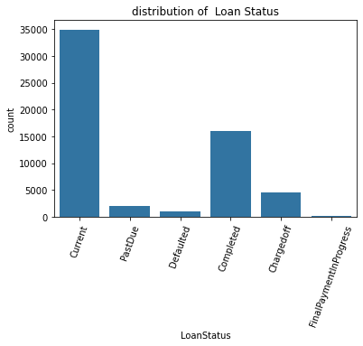

```python
color = sb.color_palette()[0]
sb.countplot(data = df, x = 'LoanStatus', color = color)
plt.xticks(rotation = 70)
plt.title('distribution of  Loan Status');
```

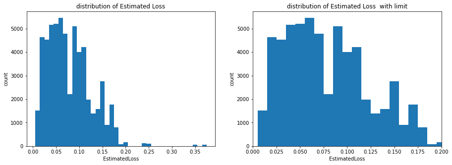

```python
plt.figure(figsize=[15, 5])


plt.subplot(1, 2, 1)
bins = np.arange(df.EstimatedLoss.min(), df['EstimatedLoss'].max()+0.01,0.01)
plt.hist(data = df, x = 'EstimatedLoss', bins = bins)
plt.xlabel('EstimatedLoss')
plt.ylabel('count')
plt.title('distribution of Estimated Loss')

plt.subplot(1, 2, 2)
bins = np.arange(df.EstimatedLoss.min(), df['EstimatedLoss'].max()+0.01,0.01)
plt.hist(data = df, x = 'EstimatedLoss', bins = bins)
plt.xlabel('EstimatedLoss');
plt.ylabel('count')
plt.title('distribution of Estimated Loss  with limit')
plt.xlim((0,0.2))


plt.show();
```

most loans has Estimated Loss in small range --> (0,0.2)

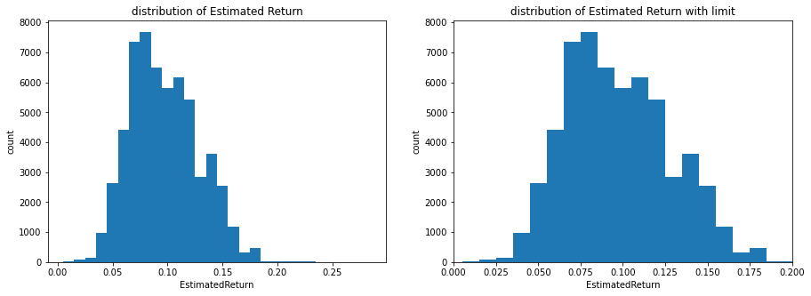

```python
plt.figure(figsize=[15, 5])


plt.subplot(1, 2, 1)
bins = np.arange(df.EstimatedLoss.min(), df['EstimatedReturn'].max()+0.01,0.01)
plt.hist(data = df, x = 'EstimatedReturn', bins = bins)
plt.xlabel('EstimatedReturn')
plt.ylabel('count')
plt.title('distribution of Estimated Return')


plt.subplot(1, 2, 2)
bins = np.arange(df.EstimatedLoss.min(), df['EstimatedReturn'].max()+0.01,0.01)
plt.hist(data = df, x = 'EstimatedReturn', bins = bins)
plt.xlabel('EstimatedReturn')
plt.ylabel('count')
plt.title('distribution of Estimated Return with limit')
plt.xlim((0,0.2))

plt.show();
```

also Estimated Return in the same range of Estimated Loss but it is seems like normal distribution

```python
df.LoanOriginalAmount.describe()
```

```
count    58539.000000
mean      8483.249936
std       6090.787395
min       1000.000000
25%       4000.000000
50%       7000.000000
75%      12000.000000
max      35000.000000
Name: LoanOriginalAmount, dtype: float64
```

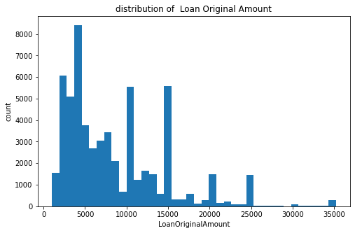

```python
# start with a standard-scaled plot
bins = np.arange(df.LoanOriginalAmount.min(), df.LoanOriginalAmount.max()+900,900)
plt.figure(figsize=[8, 5])
plt.hist(data = df, x = 'LoanOriginalAmount', bins = bins)
plt.title('distribution of  Loan Original Amount')
plt.xlabel('LoanOriginalAmount')
plt.ylabel('count');
```